# Airbnb_project

# Airbnb listings analysis project

*by Océane Salmeron, Nathan Lancman, Charles Mabbyalas, Baptise Lafay (ING5, BDA 2)*

Airbnb data contains a lot of value.

A real estate investor is looking forward to using this data in order to take a decision regarding the best option he has in real estate to generate profit on Airbnb from his investment.

He downloaded the latest available data at a specific time about the following cities:

- Malaga
- Mallorca
- Sevilla

He’s looking forward to answering the following questions:

# Analysis 1 : Comparing Cities

### 1)Find the “average availability over 30 days” of listings per each city.

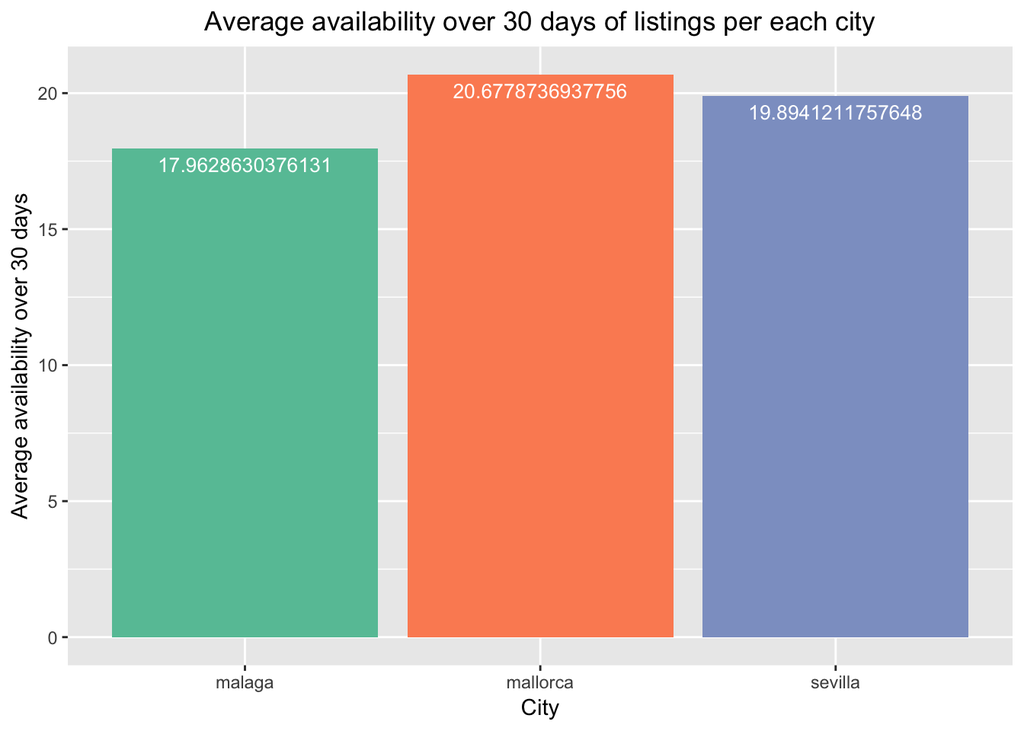

### 2)Find the “average revenue of over 30 days” of listings per each city.

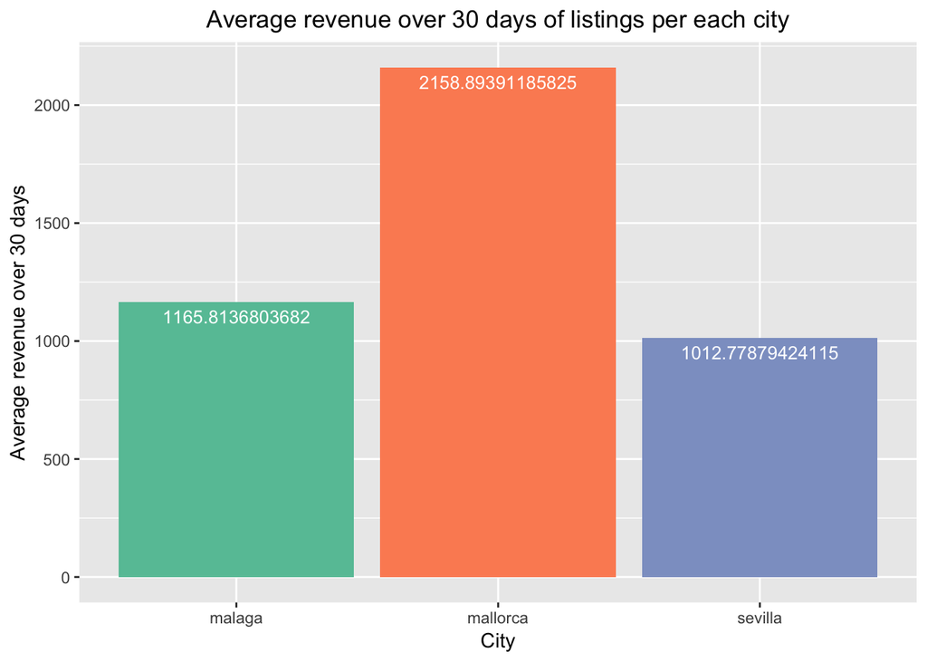

### 3)Compare the distribution of estimated availability for the next 30 days of listings per each city.

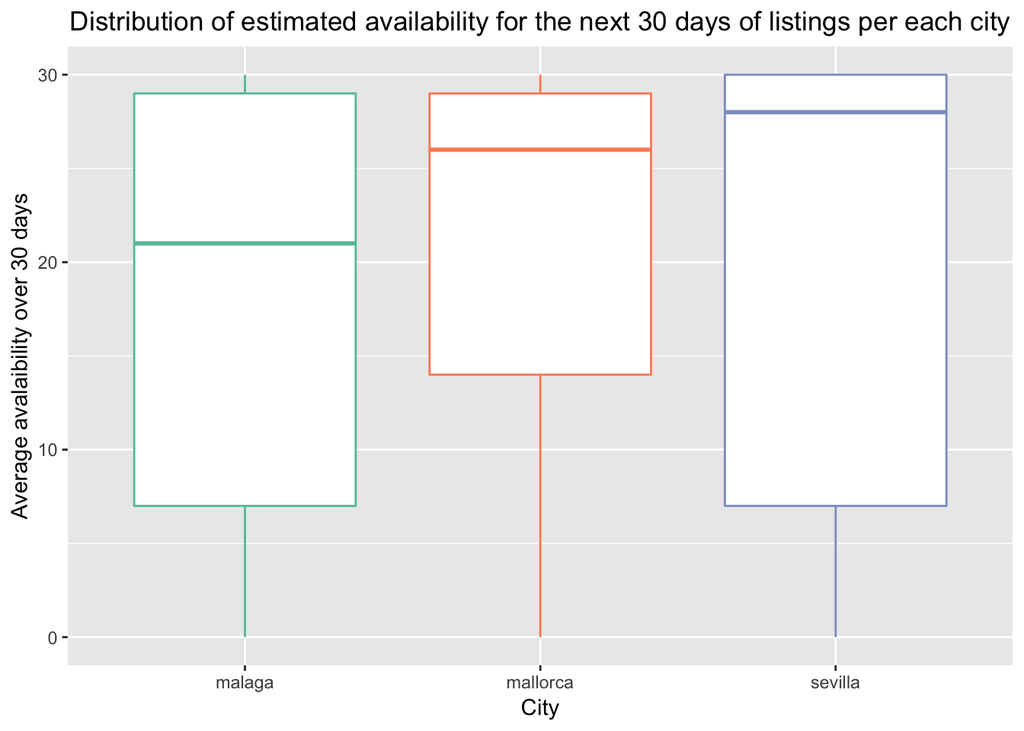

### 4)Compare the distribution of estimated revenue for the next 30 days of listings per each city.

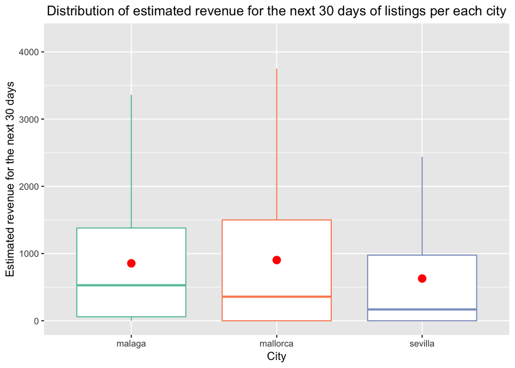

### 5)Compare the distribution of estimated revenue for the next 30 days of listings per each city & for each house size (# of bedrooms).

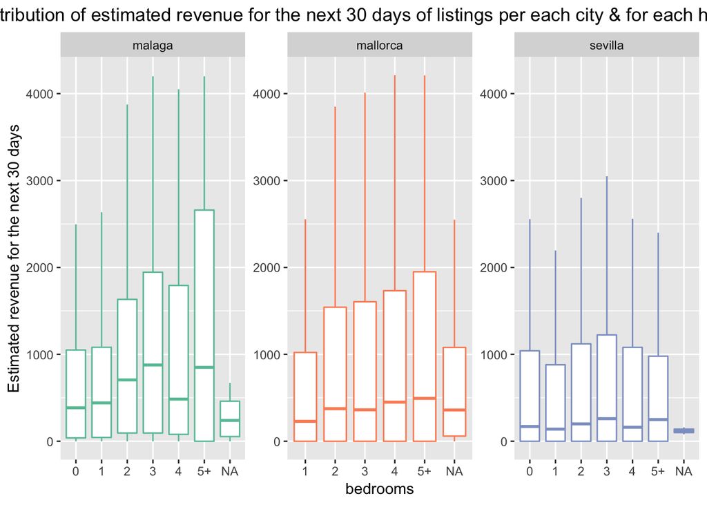

### 6)Compare the distribution of estimated revenue for the next 30 days of listings per each city & for each room type (room_type).

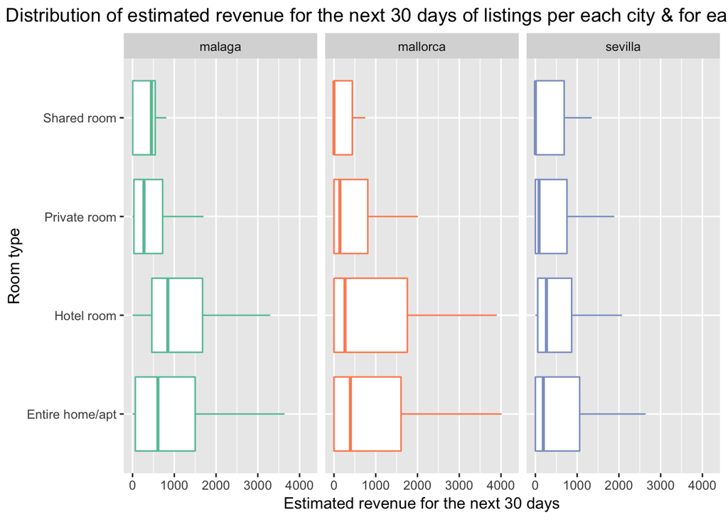

## Analyse 2 : Deep Dive in one City Analysis

### 1)What is the proportion of each room type?

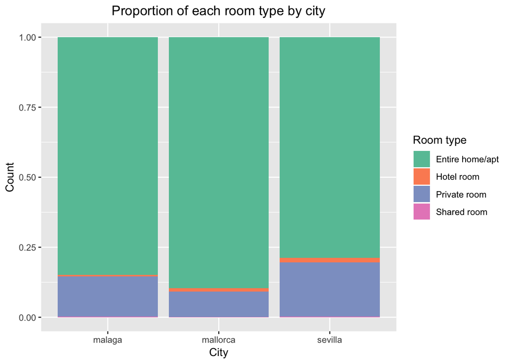

### 2)hat is the proportion of each house size (# of bedroom)?

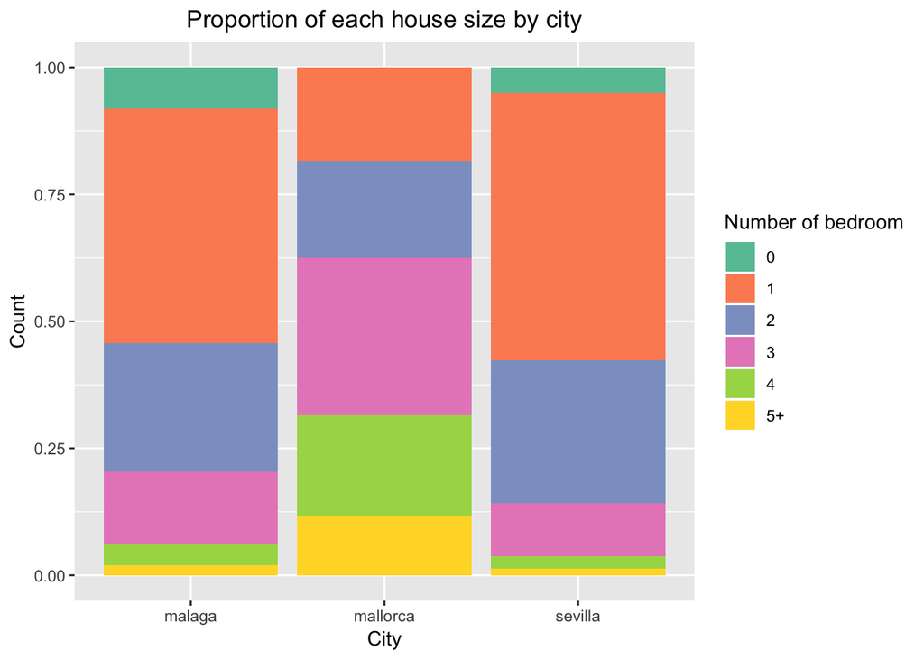

### 3)What is the proportion of each neighborhood?

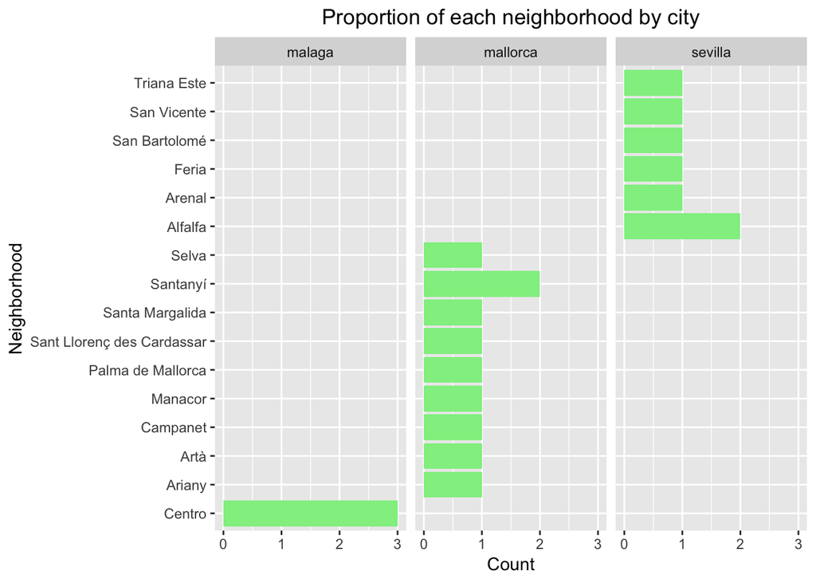

### 4)What is the average availability over the next 30 days for each room type / house size / neighborhood?

#### 4.1)Room type

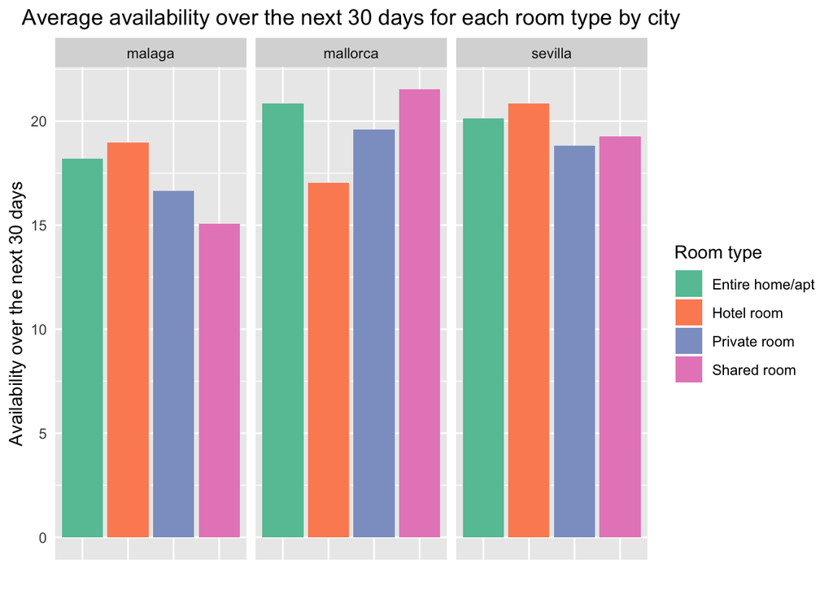

#### 4.2)House size

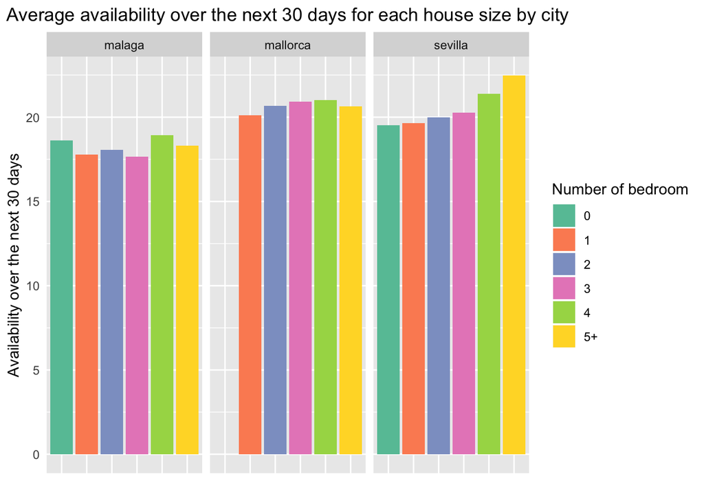

#### 4.3)Neighbourhood

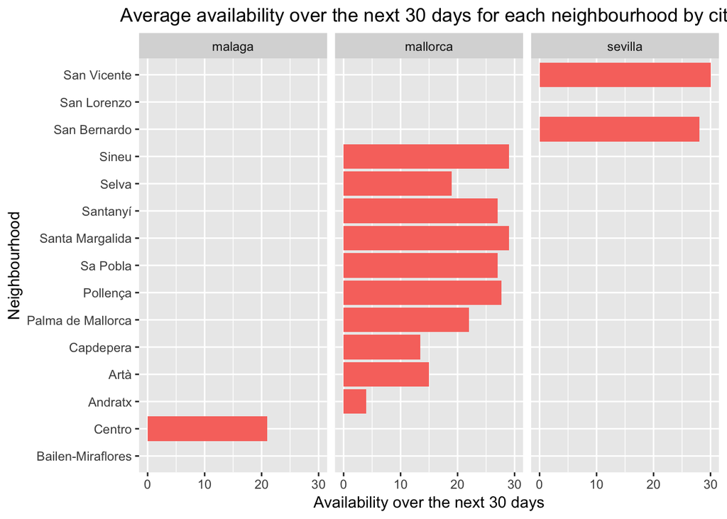

### 5)What is the average revenue over the next 30 days for each room type / house size / neighborhood?

#### 5.1)Room type

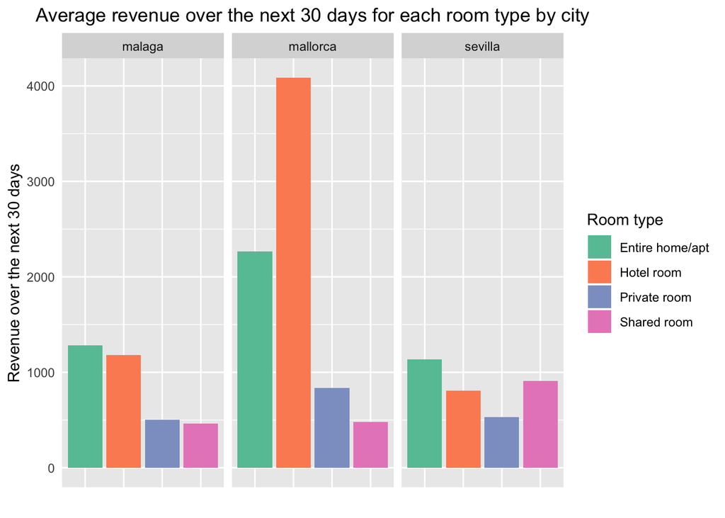

#### 5.2)House size

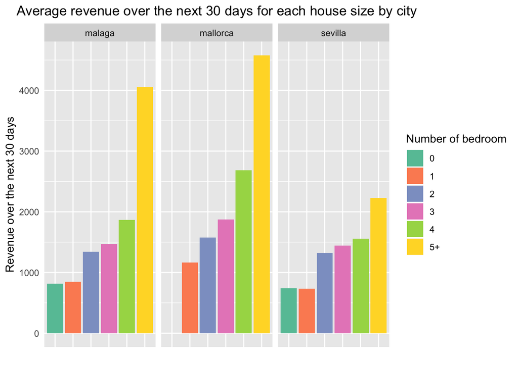

#### 5.3)Neighbourhood

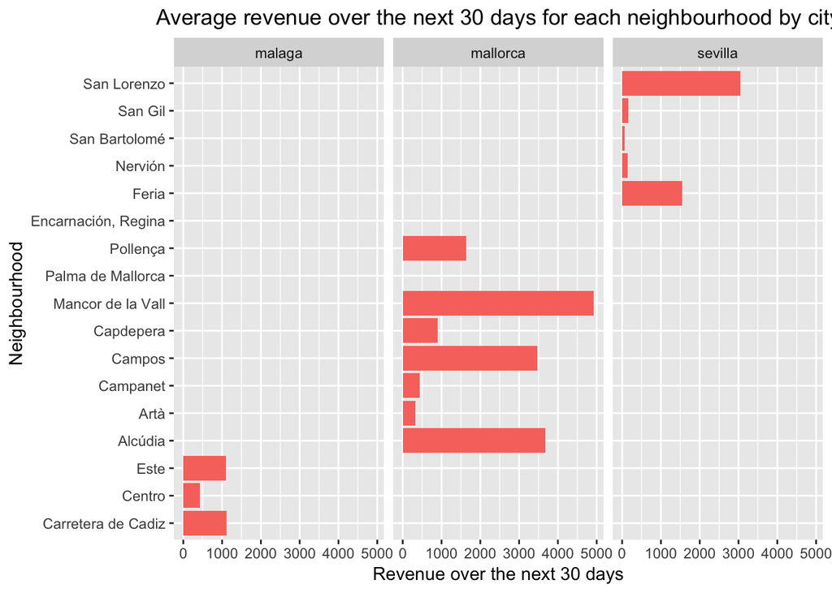

### 6)What is the distribution of availability over the next 30 days for each room type / house size / neighborhood?

#### 6.1)Room type

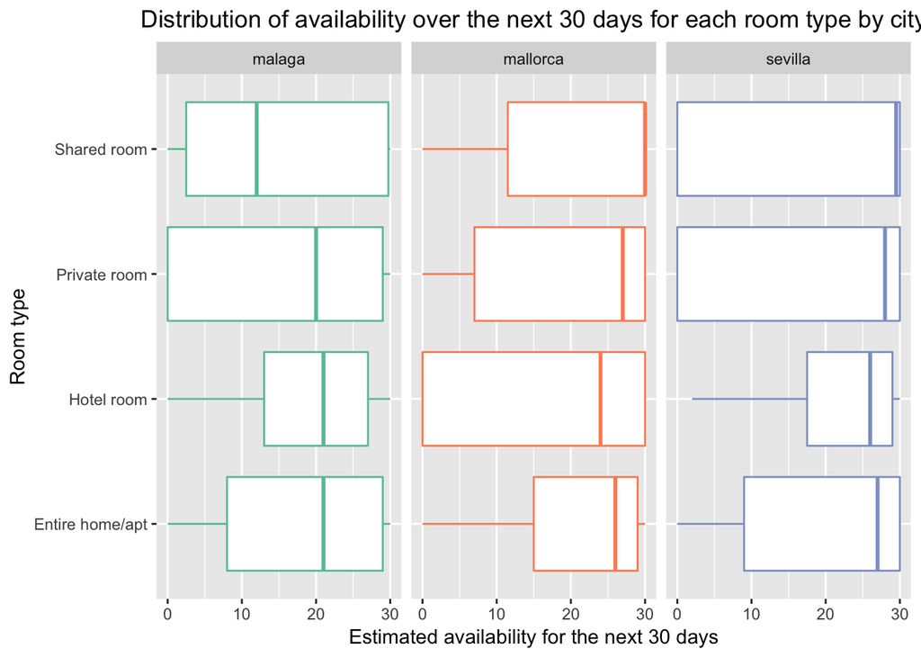

#### 6.2)House size

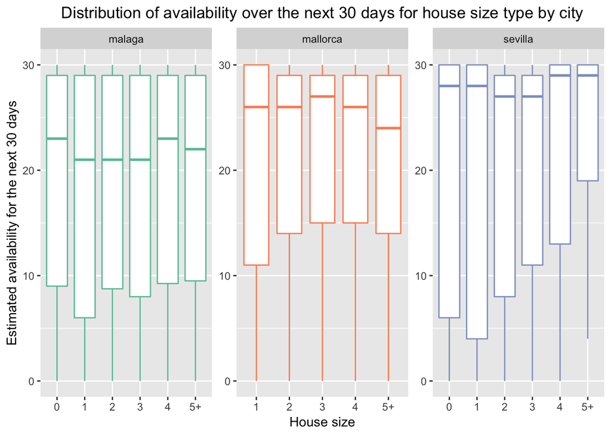

#### 6.3)Neighbourhood

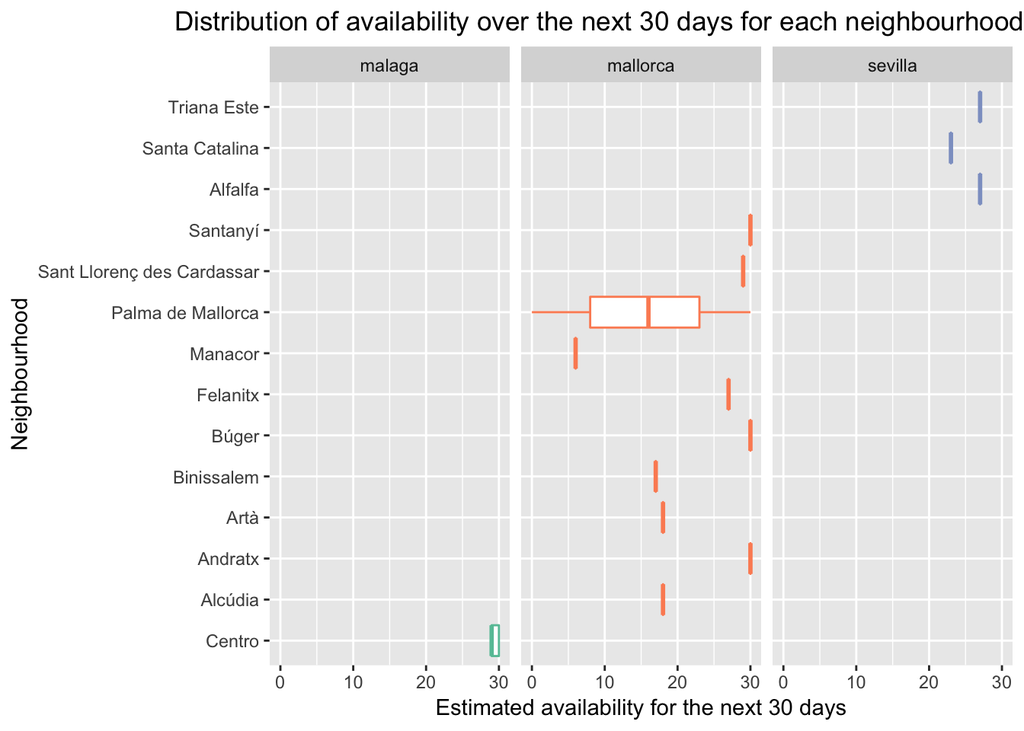

### 7)What is the distribution of revenue over the next 30 days for each room type / house size / neighborhood?

### 7.1)Room type

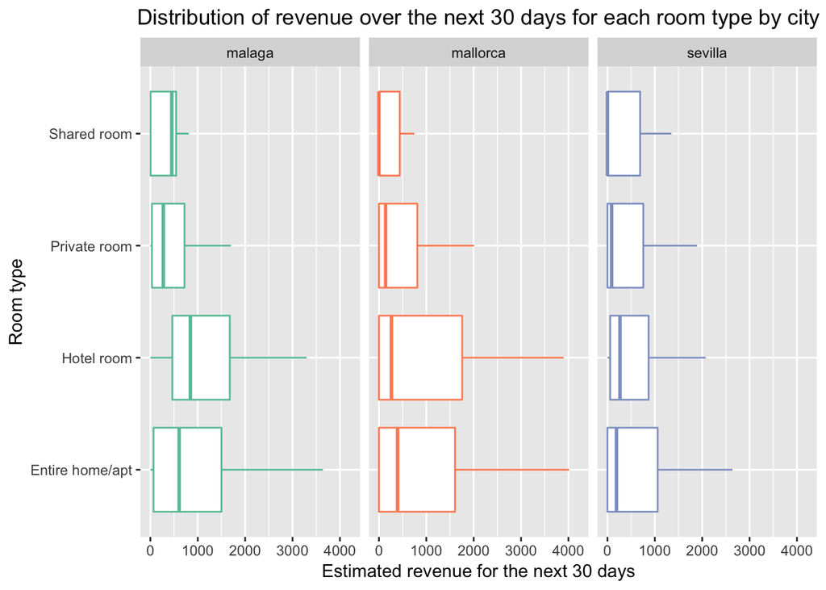

#### 7.2)House size

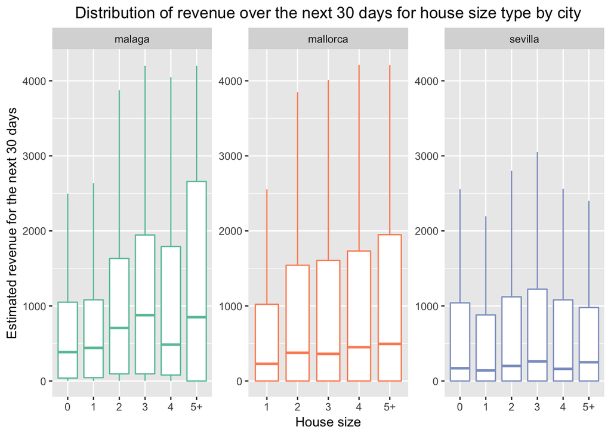

#### 7.3)Neighbourhood

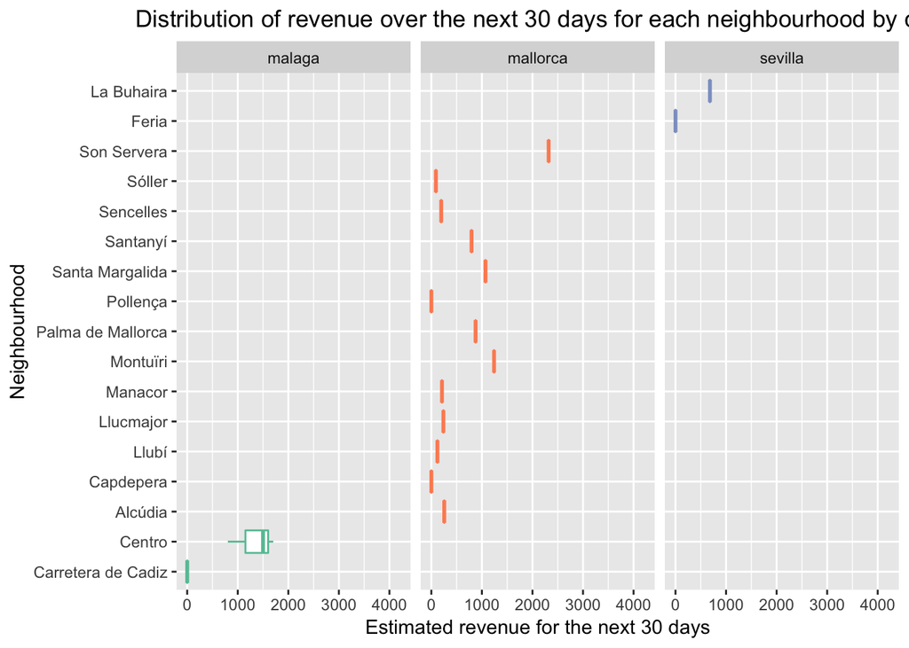